[figure not shown]

Introduction to Natural Language Processing (Part I- R)

Natural Language Processing (NLP) is a branch of Artificial Intelligence (AI) that allows computer programs to process and analyze unstructured data, such as free-text notes written by physicians/nurses in Electronic Health Records (EHRs). This technique can be used to extract useful information from unstructured data sources such as text, speech, and social media posts for various purposes such as sentiment analysis, information extraction, and named entity recognition. Organizations looking to leverage their data to improve outcomes, reduce costs, and advance medical research should consider the vast insights contained in the text and how [NLP](https://www.healthcatalyst.com/insights/healthcare-nlp-4-essentials) can be used to extract value from that data. In this handout, we review the basic concepts of **text mining**, including:

> - Data cleaning and pre-processing, including Stemming, Stopword removal, and generalization
> - Information extraction using **lexical association**
> - Sentiment analysis

In our second lecture on NLP, we will cover the **unsupervised information extraction** topic. This approach will be used to identify and extract the main topics discussed in a set of text documents by grouping similar words together and assigning them to specific topics.

Text mining in R

In R, [text mining packages](https://eight2late.wordpress.com/2015/05/27/a-gentle-introduction-to-text-mining-using-r/#cut_to_chase) are not installed by default, so one has to install them manually. The relevant packages are:

- `tm` – the text mining package.
- `SnowballC` – required for stemming.
- `wordcloud` – which is self-explanatory.

```
For Windows users: R is case-sensitive so Wordcloud != wordcloud)
```

```r
library(tm)
library(dplyr)
library(SnowballC) #for text Stemmign
# library(hunspell) # for spell check and spelling
library(ggplot2)
library(igraph)
library(ggraph)
library(tidytext)
library(wordcloud)
library(tidyr)
library(stringr)
library(textdata)
library(reshape2)

# #set the working directory to the directory that includes the dataset and the source code
# setwd(dirname(rstudioapi::getActiveDocumentContext()$path))

#read the data from URL
df <- read.csv("https://raw.githubusercontent.com/HIVE-UofT/Health-Data-Visualization/main/Lecture03/vaccination_tweets.csv")
```

```r
#set the theme
theme_update(
  plot.background = element_rect(fill = "#FFFFFF", color = "#FFFFFF"),
  panel.background = element_rect(fill = "#FFFFFF", color = NA),
  axis.text.x = element_text(angle=45, face = "plain", color = "black", size = 10, hjust=1, vjust = 1, margin = margin(r = 0)),
  axis.text.y = element_text(face = "plain", color = "black", size = 11, hjust = 1, margin = margin(r = 5)),
  axis.line.x = element_line(color="black", size = .5),
  axis.line.y = element_line(color="black", size = .5),
  axis.ticks = element_blank(),
  axis.title.x = element_blank(),
  axis.title.y = element_blank(),
  plot.title = element_text(face = "bold", color = "black", size = 15, hjust = 0, margin = margin(b = 5, l=0)),
  plot.subtitle = element_text(face = "plain", color = "#737c7d", size = 10, hjust = 0, margin = margin(b = 20, l=10)),
  legend.text=element_text(face = "plain", color = "black", size = 12),
  legend.title = element_text(face = "bold", color = "black", size = 12)
)
```

Corpus in R

In R, a corpus is a collection of documents (or text data) stored in a format that is easy to process and analyze, such as a plain text file or a data frame. We use the `Corpus` function from the `tm` package to convert the `text` column of our dataset to a corpus using the following instruction:

```r
#create the Corpus
tweets <- Corpus(VectorSource(df$text))
# tweets #uncomment this to see the number of tweets/documents in your dataset
```

The `Corpus()` function cannot be used directly with character values, instead, the `VectorSource()` function from the `tm` package must be employed. This function converts a vector of text strings into a corpus object, which is then stored in the corpus collection. The `VectorSource()` function accepts a **vector of text strings** as an input and returns a **corpus object**.

Data Cleaning and Pre-processing

Text analysis heavily relies on data cleaning, which can be tedious but is crucial. Dirty data can produce inaccurate results. Data cleaning is not a one-time process, rather it is an iterative one that requires multiple rounds of implementation. Sometimes, you may need more than 100 iterations to thoroughly clean the data.

The `tm` package provides various functions that facilitate the data cleaning process. To view the available options, enter `getTransformations()` in the **R** console.

```r
getTransformations()
```

```
## [1] "removeNumbers"     "removePunctuation" "removeWords"
## [4] "stemDocument"      "stripWhitespace"
```

Before applying powerful transformations, a few initial cleaning steps are required. Upon inspecting some tweets in the corpus, it can be observed that they have some peculiarities in their writing such as the absence of spaces between words separated by hashtags and URLs. Without addressing this issue, using the `removePunctuation()` transformation will result in the combination of words on either side of the symbols. To prevent this, these issues must be resolved before utilizing the transformations. Therefore, creating a custom transformation is necessary. The tm package enables this through the `content_transformer()` function.

> `content_transformer()`– This function accepts a **function** as input, which outlines the transformation to be performed. In our example below, the input function (`roSpace()`) will replace all instances of a certain character with spaces. The `gsub()` function can be used to achieve this.

```r
#create the toSpace content transformer
toSpace <- content_transformer(function(x, pattern) {return (gsub(pattern, " ", x))})
```

the gsub() function stands for “global substitution” and it is used to replace all occurrences of a specified pattern in a character string with a replacement string.

**gsub() function in R**

The “global substitution” function in R is used to replace all occurrences of a specified pattern in a character string with a replacement string.  
`In gsub(“http”, ” “, x)`, the function replaces all `http` tags with a space character.

Now we can use this content transformer to eliminate `URL` tags:

```r
#Remove hyperlinks
tweets <- tm_map(tweets, toSpace, "(f|ht)tp\\S+\\s*")

#Remove Twitter handles and hashtags
tweets <- tm_map(tweets, toSpace, "@[A-Za-z0-9]+|#[A-Za-z0-9]+")

#Remove emojies
tweets <- tm_map(tweets, toSpace, "[^\x01-\x7F]")
```

To to match all possible URLs, we use the `"(f|ht)tp\\S+\\s*"` regular expression. This expression detects URLs that begin with `http` or `https` and end with a whitespace character.

Different parts of this regular expression work as below:

> - `(f|ht)`: Matches either “f” or “ht”
> - `tp\\S+`: Matches “tp” followed by one or more non-whitespace characters
> - `\\s*`: Matches zero or more whitespace characters

If the text appears to be in good shape, we can proceed with the `removePunctuation` transformation. It can be applied by using the following method:

```r
#Remove punctuation – replace punctuation marks with " "
tweets <- tm_map(tweets, removePunctuation)
```

If all is well, you can move to the next step, which is to:

- Transform the corpus to lower case
- Eliminate all digits.

R is case-sensitive, meaning “Vaccine” is not the same as “vaccine”. Therefore, converting to a standard case is necessary. However, the `tolower` transformation is not included in the standard `tm` transformations. To use it for a corpus object, it must be converted into a proper transformation with the help of `content_transformer`. Here is the relevant code:

```r
#Transform to lower case (need to wrap in content_transformer)
tweets <- tm_map(tweets,content_transformer(tolower))
```

Text analysis often disregards numbers as they do not usually add meaning to the text. However, there can be exceptions to this, for instance, when counting the occurrences of a specific year within a corpus. This can be done using the standard transformation `removeNumbers()` in the `tm` package, which does not require the use of `content_transformer()`.

```r
#Eliminate digits
tweets <- tm_map(tweets, removeNumbers)
```

> Stop words are commonly used words that carry little meaning and are not helpful for many NLP tasks. Including them in the analysis can add noise to the data and make it harder to extract meaningful information. On the other hand, removing stop words can also help reduce the data’s dimensionality and improve the performance of NLP algorithms.

The next step is to eliminate frequently used words from the text, such as articles (a, an, the), conjunctions (and, or, but, etc.), common verbs (is), and qualifiers (yet, however, etc). The `tm` package has a built-in list of these so-called **stop words**. We can remove them by using the standard `removeWords` transformation, which is applied as follows:

```r
#remove stopwords using the standard list in tm
tweets <- tm_map(tweets, removeWords, stopwords("english"))
```

Finally, we get rid of any additional white spaces that have accumulated during the cleaning process using the `stripWhitespace` transformation:

```r
#Strip whitespace
tweets <- tm_map(tweets, stripWhitespace)
```

Stemming

```r
writeLines(as.character(tweets[[2650]]))
```

```
## dad got st part pfizer covid vaccine today just case youre wondering hes adverse reaction
```

Now let’s apply stemming to the corpus and take another look at it.

```r
tweets <- tm_map(tweets,stemDocument)
writeLines(as.character(tweets[[2650]]))
```

```
## dad got st part pfizer covid vaccin today just case your wonder hes advers reaction
```

Document Term Matrix (DTM)

DTM stands for Document-Term Matrix, it is a matrix that records the presence and number of occurrences of words in a corpus by documents. The documents are represented by rows and the words are represented by columns. If a word appears in a specific document, the corresponding entry in the matrix is marked as “1” and if not it is marked as “0”, multiple occurrences within a document will be recorded as the number of occurrences. If we take a Twitter corpus as an example, the DTM will look like this:

```r
#Create a term-document matrix from the corpus and stores the result in the variable dtm.
dtm <- DocumentTermMatrix(tweets)
dtm
```

```
## <<DocumentTermMatrix (documents: 11020, terms: 7941)>>
## Non-/sparse entries: 77004/87432816
## Sparsity           : 100%
## Maximal term length: 33
## Weighting          : term frequency (tf)
```

```r
inspect(dtm[1:2,900:910])
```

```
## <<DocumentTermMatrix (documents: 2, terms: 11)>>
## Non-/sparse entries: 0/22
## Sparsity           : 100%
## Maximal term length: 7
## Weighting          : term frequency (tf)
## Sample             :
##     Terms
## Docs moderna requir special advers anthrax maim mandat serious soldier cell
##    1       0      0       0      0       0    0      0       0       0    0
##    2       0      0       0      0       0    0      0       0       0    0
##     Terms
## Docs protein
##    1       0
##    2       0
```

[figure not shown]

Mining the Corpus

Keep in mind that by creating the DTM, we have transformed a corpus of text into a mathematical object that can be studied using quantitative methods of matrix algebra. Therefore, the DTM is the foundation for quantitative text analysis. For instance, to determine the frequency of each word in the corpus, we simply add up all the rows to get the column sums. In this command, we first transform the DTM into a mathematical matrix using the `as.matrix()` function.

```r
freq <- colSums(as.matrix(dtm))
```

Next, we use `order()` function to sort the frequencies in a descending order according to the number of terms.

```r
#create sort order (descending)
dec_ord <- order(freq, decreasing=TRUE)
```

Then, we show the terms that occur most and least frequently.

```r
#inspect most frequently occurring terms
freq[head(dec_ord)]
```

```
## vaccin   dose  covid  first  today    get
##   5062   2005   1517   1192    864    832
```

```r
#inspect least frequently occurring terms
freq[tail(dec_ord)]
```

```
## roundtabl      siri testimoni  schoolag   magsing      aaro
##         1         1         1         1         1         1
```

To inspect our dataset so far, let’s export the frequency data to a CSV file:

```r
write.csv(freq[dec_ord],"tweets_freq.csv")
```

```r
tweets <- tm_map(tweets, content_transformer(gsub), pattern = "coronavirus", replacement = "covid")
tweets <- tm_map(tweets, content_transformer(gsub), pattern = "pfizerbion", replacement = "pfizer")
tweets <- tm_map(tweets, content_transformer(gsub), pattern = "pfizerbi", replacement = "phizer")

#defining new stopwords
DrugStopwords <- c("can", "get", "now", "ive", "use", "one", "also", "will", "can",
                   "put", "yes", "abl", "per", "say", "take")
tweets <- tm_map(tweets, removeWords, DrugStopwords)
```

Words such as “he” and “im” do not provide any meaningful information about the subject matter of the documents in which they appear, so they can be removed without any harm. These words should have been removed earlier by the stopword removal process. However, since such words occur quite frequently in almost all documents, they can be removed by setting boundaries when creating the DTM, in the following way:

```r
dtmr <-DocumentTermMatrix(tweets, control=list(wordLengths=c(3, 20), bounds = list(global = c(3,300))))
dtmr
```

```
## <<DocumentTermMatrix (documents: 11020, terms: 2620)>>
## Non-/sparse entries: 48694/28823706
## Sparsity           : 100%
## Maximal term length: 17
## Weighting          : term frequency (tf)
```

Here we have instructed R to only include words that appear in 3 to 300 documents in the DTM. We have also set a minimum and maximum limit for the length of the words that are included, which is between 3 and 20 characters.

The next step is to compute the frequency on the modified DTM (dtmr):

```r
freqr <- colSums(as.matrix(dtmr))

#create sort order
ordr <- order(freqr,decreasing=TRUE)

#inspect most frequently occurring terms
freqr[head(ordr)]
```

```
##    week     new protect    side    work   fulli
##     302     296     278     240     234     229
```

```r
#inspect least frequently occurring terms
freqr[tail(ordr)]
```

```
##     woodcock vaccinerefus    biosafeti       unanim        renam         ampm
##            3            3            3            3            3            3
```

```r
findFreqTerms(dtmr,lowfreq=80)
```

```
##   [1] "said"      "hope"      "side"      "world"     "year"      "last"
##   [7] "even"      "need"      "anyon"     "safe"      "mani"      "start"
##  [13] "state"     "death"     "million"   "wait"      "care"      "health"
##  [19] "new"       "patient"   "safeti"    "expect"    "announc"   "hour"
##  [25] "part"      "two"       "updat"     "case"      "report"    "around"
##  [31] "make"      "author"    "emerg"     "fda"       "mrna"      "medic"
##  [37] "want"      "week"      "help"      "show"      "test"      "well"
##  [43] "far"       "news"      "pleas"     "give"      "come"      "final"
##  [49] "administ"  "biontech"  "like"      "trial"     "arriv"     "import"
##  [55] "great"     "nurs"      "scientist" "morn"      "made"      "next"
##  [61] "see"       "avail"     "worker"    "let"       "number"    "clinic"
##  [67] "observ"    "follow"    "work"      "read"      "everyon"   "hospit"
##  [73] "look"      "countri"   "offer"     "protect"   "scienc"    "way"
##  [79] "immun"     "good"      "happi"     "given"     "month"     "may"
##  [85] "still"     "full"      "end"       "develop"   "via"       "team"
##  [91] "age"       "group"     "data"      "live"      "call"      "grate"
##  [97] "arm"       "sore"      "think"     "know"      "sinc"      "yesterday"
## [103] "reaction"  "inject"    "time"      "moderna"   "govern"    "staff"
## [109] "post"      "delay"     "efficaci"  "old"       "right"     "studi"
## [115] "complet"   "rememb"    "children"  "die"       "variant"   "booster"
## [121] "fulli"     "measur"
```

Before creating visual representation of the word/frequency data, we have to convert it into a dataframe:

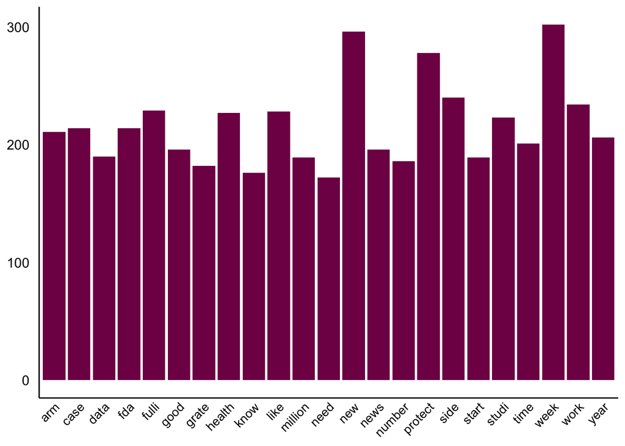

```r
data_frame = data.frame(term=names(freqr), occurrences=freqr)

# Frequency Barchart
p <- ggplot(subset(data_frame, freqr>170), aes(term, occurrences))
p <- p + geom_bar(stat="identity", fill="#801255")
p <- p + theme(axis.text.x=element_text(angle=45, hjust=1))
p
```

In the end, we will create a wordcloud to display the most common words in our corpus. The code to do this is as follows:

> In R, the `brewer.pal()` function is used to create a color palette based on the “ColorBrewer” guidelines. The function takes a number of arguments, including the palette’s name (e.g., “YlGn”), the number of colors in the palette, and whether the colors should be reversed. The function’s output is a vector of colors that can be used in a plot. Additional color options can be found [here](https://earlglynn.github.io/RNotes/package/RColorBrewer/index.html).

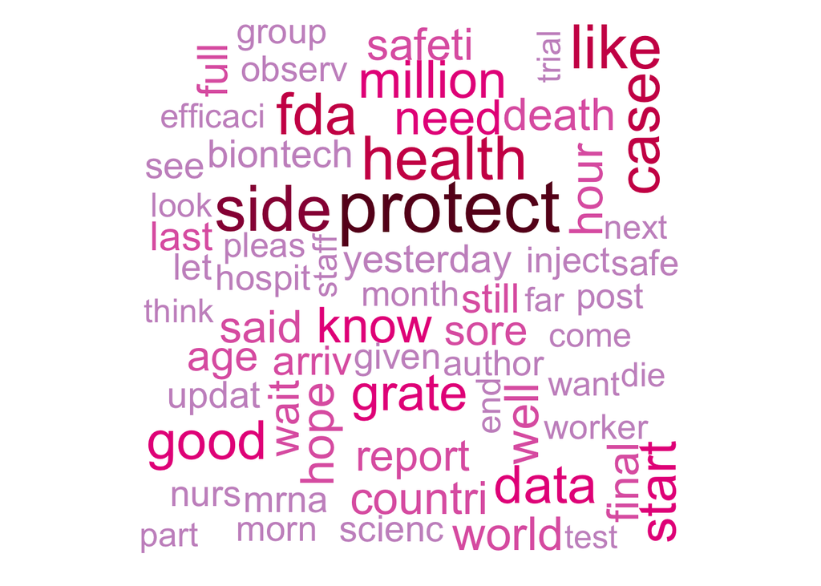

```r
#setting the same seed each time ensures consistent look across clouds
set.seed(42)

#limit words by specifying min frequency

wordcloud(names(freqr), freqr,min.freq=100, colors=brewer.pal(9,"PuRd"))
```

Now that we have the most frequently occurring terms, we can investigate the relationship between some of these terms and other terms that appear in the corpus. In this context, correlation represents a quantitative measure of how often words appear together in multiple documents. The `tm` package offers the function `findAssocs()` to perform this task. The user needs to provide the DTM, the term of interest, and the correlation limit. Here are the results obtained when using `findAssocs()` on some of the frequent terms (pain, feel).

```r
findAssocs(dtm,"pain",0.1)
```

```
## $pain
##          muscl         intens        rheumat         inject          chest
##           0.26           0.24           0.23           0.20           0.20
##           site          joint            hrs          fever          moder
##           0.16           0.15           0.14           0.13           0.13
##        persist           tire    psychosomat         thinki         dental
##           0.13           0.12           0.12           0.12           0.12
##         gawand          perth           brou            mod          vomit
##           0.12           0.12           0.12           0.12           0.12
##          woope          resea       indigest       axillari         enlarg
##           0.12           0.12           0.12           0.12           0.12
##         milder         lessen            ank armannoyingnot          thump
##           0.12           0.12           0.12           0.12           0.12
##           usua      heartbeat         allmal         medium         killer
##           0.12           0.12           0.12           0.12           0.12
##    formercovid        afebril          sharp            arm           dull
##           0.12           0.12           0.12           0.11           0.11
##           doze          tired            day          sleep         nausea
##           0.11           0.11           0.10           0.10           0.10
##          shoot          swell
##           0.10           0.10
```

```r
findAssocs(dtm,"feel",0.1)
```

```
## $feel
##    lucki     fine     like privileg   crappi    great     post
##     0.17     0.15     0.12     0.12     0.12     0.11     0.11
```

Examine these associations and connect them with other columns in the dataset. Are there any noteworthy discoveries?

Unsupervised Information Extraction

Unsupervised information extraction automatically extracts insight from unstructured text data without using labeled examples or prior knowledge. This approach aims to discover and extract hidden patterns, relationships, and structures from text data without human supervision. This is in contrast to supervised information extraction, which uses labeled examples to train a model to extract specific types of information. In this section, we will explore some of the methods that `tidytext` library offers for calculating and visualizing relationships between words in the vaccine datasets. This includes the `token = "ngrams"` argument, which tokenizes by pairs of adjacent words rather than by individual ones. We will also introduce a new package: `ggraph`, which extends `ggplot2` to construct network plots.

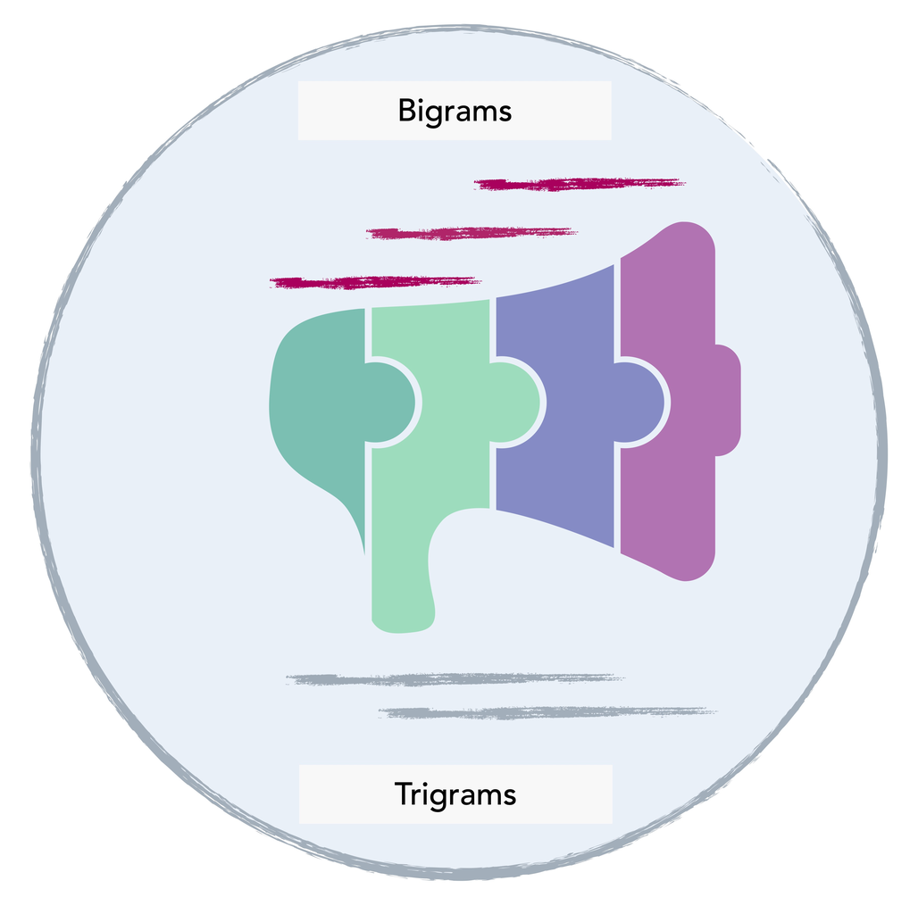

Language Models

A machine learning model that is trained to predict the likelihood of a set of words based on preceding words is called a **language model**. These models are applied in a variety of natural language processing (NLP) operations including speech recognition, machine translation, text generation, and text summarization. In this course, we will be utilizing Statistical Language Models, which are constructed using a large corpus of text data and rely on statistical techniques to compute the probability of a word or sequence of words.

N-grams

An **n-gram** is a method of statistical language modeling that assesses the likelihood of a word based on the co-occurrence of words in a text. It estimates the probability of a word given the previous `n-1` words. For example, a **bigram** (n=2) model estimates the probability based on the preceding word, and a trigram model estimates the probability based on the preceding two words. This approach assumes that the probability of a word is only dependent on the previous `n-1` words. N-grams are commonly employed in various NLP tasks, such as speech recognition, machine translation, and text prediction. For example, the bigrams (n=2) of the sentence `the COVID vaccines work well enough` are:

- “the COVID”
- “COVID vaccines”
- “vaccines work”
- “work well”
- “well enough”

Or the trigrams of the same sentenceare:

- “the COVID vaccines”
- “COVID vaccines work”
- “vaccines work well”
- “work well enough”

We create language models for our Twitter dataset by dividing tweets into sets of consecutive words (n-grams) using the `unnest_tokens()` function. We then use the frequency of word ‘X’ being followed by word ‘Y’ to build a model that shows their relationship. We use the `iconv()` function to change the encoding of a character vector. This function requires two inputs: the vector to be converted, and the desired encoding. For instance, we use it to change the encoding of vector x from “UTF-8” to ASCII. This function is beneficial when working with text data that may be encoded differently and it is important to standardize it for proper processing.

```r
df$text <- lapply(df$text, as.character) #in case the format of the text column is 'factor' //check class(df$text)
df$text <- as.character(unlist(df$text)) #to unlist the list to character format
df$text <- iconv(df$text, "UTF-8", "ASCII", sub="") #To remove all the special characters from text

df$text <-stemDocument(df$text) #stemming the document
```

Let’s investigate the most frequent bi-grams in our dataset by utilizing the `count()` function from the `dplyr` package.

```r
# Removing the stopwords, handles, and hashtage
df$text<-tolower(df$text) %>%gsub(pattern = "(f|ht)tp\\S+\\s*", replace = " ", df$text)%>%
  gsub(pattern = "@[A-Za-z0-9]+|#[A-Za-z0-9]+", replace = " ", df$text)%>%
  gsub(pattern = "[^\x01-\x7F]", replace = " ", df$text)

bigrams <- df %>% tidytext::unnest_tokens(bigram, text, token = "ngrams", n = 2)
bigrams %>% count (bigram, sort=TRUE)
```

[output not shown]

As expected, many of the most common bigrams are pairs of frequent (unimportant) words, such as “of the” and “in the”, which are known as “stop-words”. To overcome this, we use the `separate()` function from `tidyr`, which splits a column into multiple based on a delimiter. This enables us to separate the bigrams into two columns, “word1” and “word2”, and then we can eliminate cases where either of them is a stop-word or irrelevant.

```r
# #-------------Try TM-------

bigrams_separated <- bigrams %>%
  separate(bigram, c("word1", "word2"), sep = " ")

context_w1 <- c("the", "my", "to" ) #contextual words that should be removed! Separate them by ','
context_w2<- c("19", "in") #do the same for the second word!


data(stop_words)
bigrams_filtered <- bigrams_separated %>%
  filter(!word1 %in% stop_words$word) %>%
  filter(!word2 %in% stop_words$word)%>%
  filter(!str_detect(word1, "^[0-9]*$")) %>% #removing numbers from word1
  filter(!str_detect(word2, "^[0-9]*$")) %>% #removing numbers from word2
  filter(!word1 %in% context_w1) %>%
  filter(!word2 %in% context_w2)
```

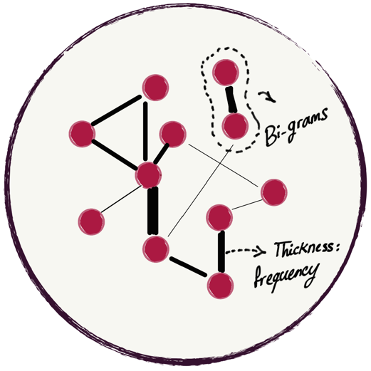

Visualizing the Relationships between Words (N-grams)

We may be interested in visualizing all of the relationships among words simultaneously, rather than just the top few at a time. As one common visualization, we can arrange the words into a **network**, or **graph**. Here we will be referring to a *graph* not in the sense of a visualization, but as a combination of connected nodes. A graph can be constructed from a tidy object since it has three variables:

- **from**: the node an edge is coming from
- **to**: the node an edge is going towards
- **weight**: A numeric value associated with each edge

The `igraph` package has many powerful functions for manipulating and analyzing networks. One way to create an igraph object from tidy data is the `graph_from_data_frame()` function, which takes a data frame of edges with columns for `from`, `to`, and `edge` attributes (in this case n):

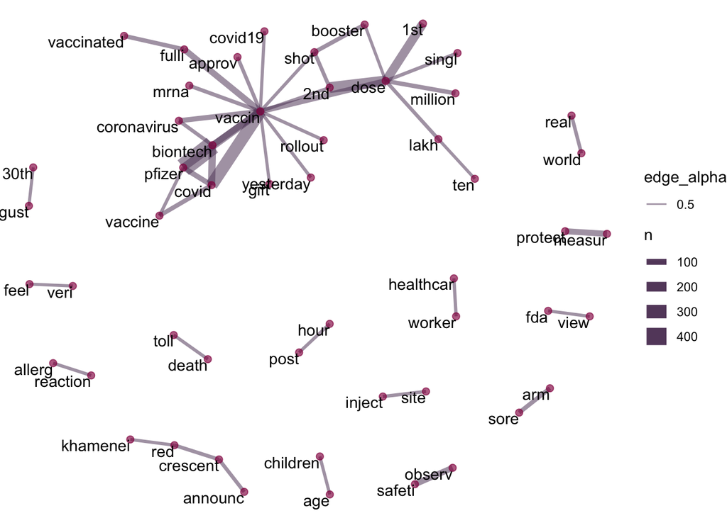

```r
#------------------Generating bi-grams--------------
bigram_counts <- bigrams_filtered %>%
  count(word1, word2, sort = TRUE)

#---------------------Generating Graphs---------------------------

set.seed(2017)

bigram_counts %>%
filter(n > 25) %>%
graph_from_data_frame() %>%
ggraph(layout = "fr") +
geom_edge_link(aes(edge_alpha=.5, edge_width=n), edge_color="#64486b") +
geom_node_point(color = "#940d4e", size = 2, alpha=0.65) +
geom_node_text(aes(label = name), vjust = 1, hjust = 1)+
theme_void()
```

```r
ggsave("Graph.png", width = 6, height = 6)
```

We can make the graph directional to show the order of words:

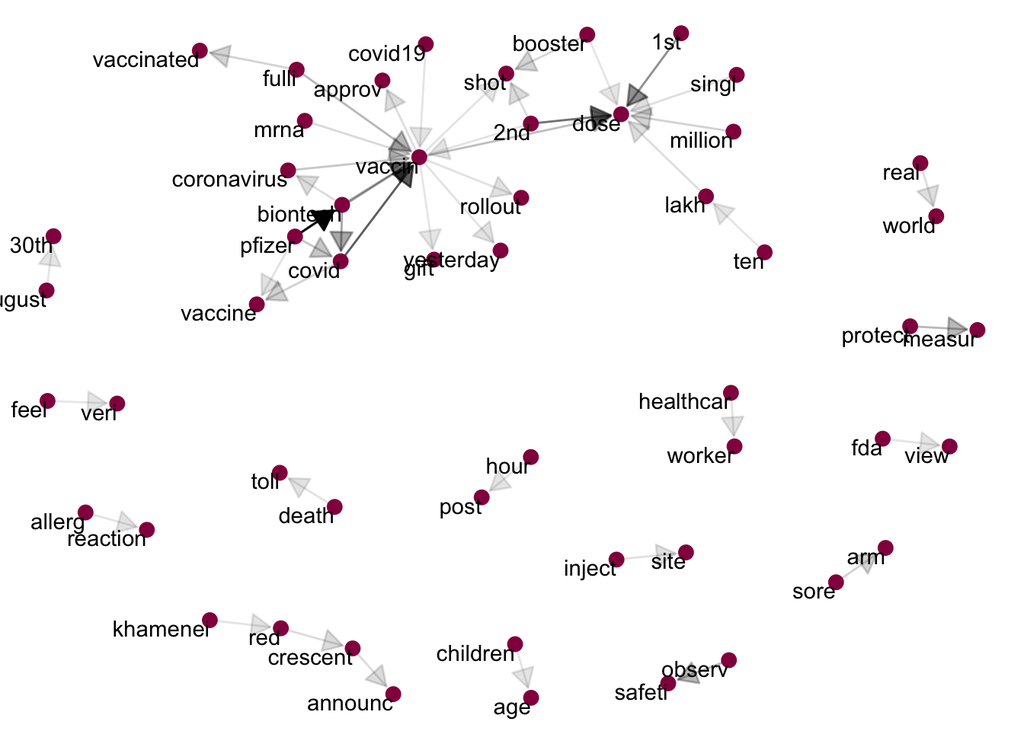

```r
set.seed(2017)

a <- grid::arrow(type = "closed", length = unit(.15, "inches"))
 bigram_counts %>%
  filter(n > 25) %>%
  graph_from_data_frame() %>%
  ggraph(layout = "fr") +
  geom_edge_link(aes(edge_alpha = n*2), show.legend = FALSE,
                 arrow = a, end_cap = circle(.07, 'inches')) +
  geom_node_point(color = "#940d4e", size = 3) +
  geom_node_text(aes(label = name), vjust = 1, hjust = 1) +
  theme_void()
```

[figure not shown]

```r
ggsave("Graph-Directed.png", width = 10, height =6)
```

Information Extraction Using Sentiment Analysis

Sentiment analysis determines the emotional tone behind a text, typically to determine whether it is positive, negative, or neutral. This can be done using various techniques, such as natural language processing, machine learning, and text analytics. Sentiment analysis is commonly used in areas such as marketing, customer service, and public opinion research.

There are various methods and dictionaries available to evaluate the sentiment or emotion in text. The `tidytext` package includes several sentiment lexicons. Three general-purpose lexicons that come with the package are:

- **AFINN** from Finn Arup Nielsen,
- **bing** from Bing Liu and collaborators, and
- **nrc** from Saif Mohammad and Peter Turney.

```r
get_sentiments("afinn")
```

```
## # A tibble: 2,477 × 2
##    word       value
##    <chr>      <dbl>
##  1 abandon       -2
##  2 abandoned     -2
##  3 abandons      -2
##  4 abducted      -2
##  5 abduction     -2
##  6 abductions    -2
##  7 abhor         -3
##  8 abhorred      -3
##  9 abhorrent     -3
## 10 abhors        -3
## # … with 2,467 more rows
```

```r
get_sentiments("bing")
```

```
## # A tibble: 6,786 × 2
##    word        sentiment
##    <chr>       <chr>
##  1 2-faces     negative
##  2 abnormal    negative
##  3 abolish     negative
##  4 abominable  negative
##  5 abominably  negative
##  6 abominate   negative
##  7 abomination negative
##  8 abort       negative
##  9 aborted     negative
## 10 aborts      negative
## # … with 6,776 more rows
```

```r
get_sentiments("nrc")
```

```
## # A tibble: 13,872 × 2
##    word        sentiment
##    <chr>       <chr>
##  1 abacus      trust
##  2 abandon     fear
##  3 abandon     negative
##  4 abandon     sadness
##  5 abandoned   anger
##  6 abandoned   fear
##  7 abandoned   negative
##  8 abandoned   sadness
##  9 abandonment anger
## 10 abandonment fear
## # … with 13,862 more rows
```

With data in a tidy format, sentiment analysis can be done as an `inner join` operation (Check Lecture 2 for more details about `join` operations:

```r
tidy <- df %>% tidytext::unnest_tokens(word, text) %>%
  mutate(word_stem = wordStem(word, language="english"))
```

```r
bing_word_counts <- tidy %>%
  inner_join(get_sentiments("bing")) %>%
  count(word, sentiment, sort = TRUE)

bing_word_counts
```

This can be shown visually as:

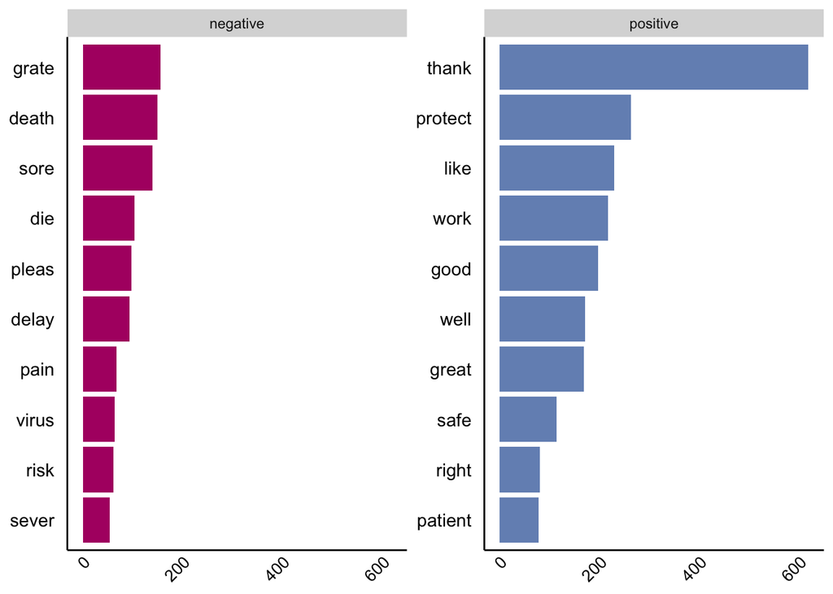

```r
bing_word_counts %>%
  group_by(sentiment) %>%
  top_n(10) %>%
  ungroup() %>%
  mutate(word = reorder(word, n)) %>%
  ggplot(aes(word, n, fill = sentiment)) +
  scale_fill_manual(values = c("#b01371", "#7591bf")) +
  geom_col(show.legend = FALSE) +
  facet_wrap(~sentiment, scales = "free_y") +
  labs(y = "Contribution to sentiment",
       x = NULL) +
  coord_flip()
```

To use the `comparison.cloud()` function, you may need to turn the data frame into a matrix with `reshape2`’s `acast()`. Let’s do the sentiment analysis to tag positive and negative words using an inner join, then find the most common positive and negative words. Until the step where we need to send the data to comparison.cloud(), this can all be done with **joins**, **piping**, and **dplyr** because our data is in **tidy** format.

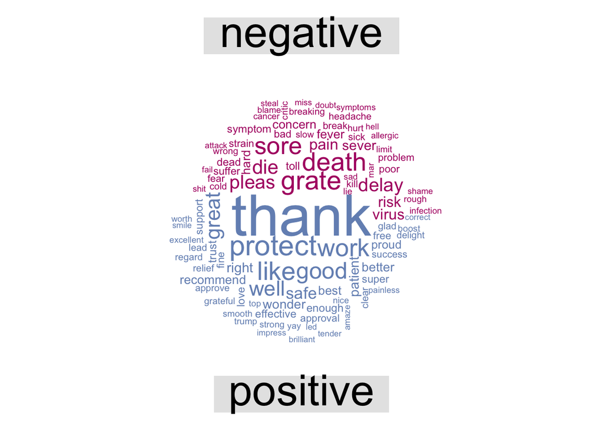

```r
#acast() converts a long-format data frame into a wide-format vector/matrix/array.

tidy %>%
  inner_join(get_sentiments("bing")) %>%
  count(word, sentiment, sort = TRUE) %>%
  acast(word ~ sentiment, value.var = "n", fill = 0) %>%
  comparison.cloud(colors = c("#b01371", "#7591bf"),
                   max.words = 100)
```

Now that we have the data organized into bigrams, it is easy to tell how often words are preceded by a word like `not`:

```r
bigrams_separated %>%
  filter(word1 == "not") %>%
  count(word1, word2, sort = TRUE)
```

By performing sentiment analysis on the bigram data, we can examine how often sentiment-associated words are preceded by **not** or other negating words. We could use this to ignore or even reverse their contribution to the sentiment score.

```r
AFINN <- get_sentiments("afinn")
```

Let’s examine the most frequent words that were preceded by “not” and were associated with a sentiment.

```r
not_words <- bigrams_separated %>%
  filter(word1 == "not") %>%
  inner_join(AFINN, by = c(word2 = "word")) %>%
  count(word2, value, sort = TRUE)

not_words
```

```
##        word2 value  n
## 1     accept     1 11
## 2      allow     1  4
## 3     forget    -1  3
## 4       good     3  3
## 5      trust     1  3
## 6     afraid    -2  2
## 7   approved     2  2
## 8    certain     1  2
## 9  recommend     2  2
## 10      safe     1  2
## 11   support     2  2
## 12      want     1  2
## 13     alone    -2  1
## 14    better     2  1
```

[output cut: 20 more lines]

For example, the most common sentiment-associated word to follow “not” is **accept**, which would normally have a (positive) score of `1`.

It is worth asking which words contributed the most in the *wrong* direction. To compute that, we can multiply their value by the number of times they appear (so that a word with a value of +3 occurring 10 times has as much impact as a word with a sentiment value of +1 occurring 30 times). We visualize the result with a bar plot:

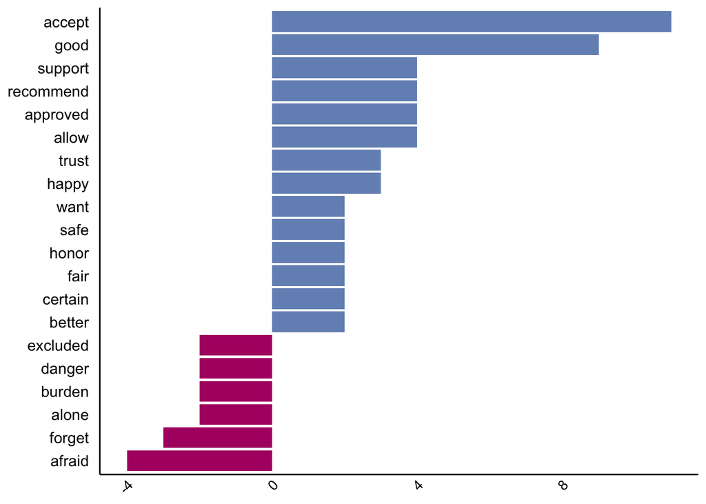

```r
not_words %>%
  mutate(contribution = n * value) %>%
  arrange(desc(abs(contribution))) %>%
  head(20) %>%
  mutate(word2 = reorder(word2, contribution)) %>%
  ggplot(aes(word2, n * value, fill = n * value > 0)) +
  scale_fill_manual(values = c("#b01371", "#7591bf")) +
  geom_col(show.legend = FALSE) +
  xlab("Words preceded by \"not\"") +
  ylab("Sentiment value * number of occurrences") +
  coord_flip()
```

“Not” is not the only term that provides some context for the following word. We could pick four common words (or more) that negate the subsequent term, and use the same joining and counting approach to examine all of them at once. Check the results with other negative words that are common in the context of your data and see the results by adding `negation_words` to the end of the following code snippet.

```r
negation_words <- c("not", "no", "never", "without")

negated_words <- bigrams_separated %>%
  filter(word1 %in% negation_words) %>%
  inner_join(AFINN, by = c(word2 = "word")) %>%
  count(word1, word2, value, sort = TRUE)
```